# Bridge River strays 2020

February 10, 2021

## Genetic vs. phenotypic sex ID

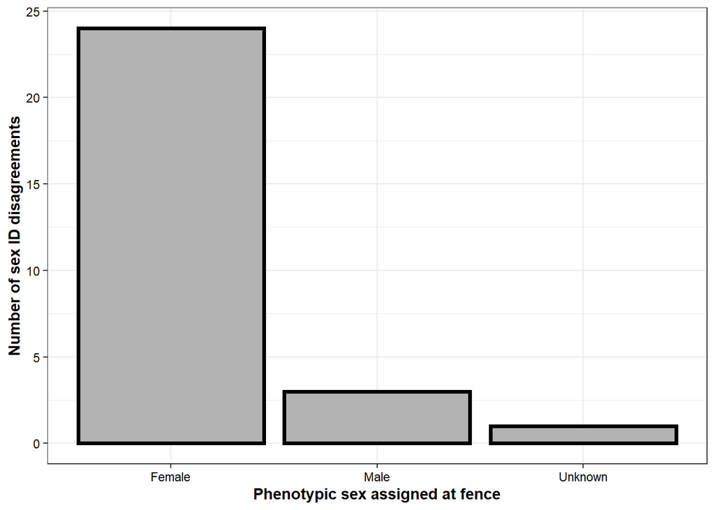

*Figure 1. Number of cases from the Bridge River fence where the sockeye phenotypic sex did not match the genetic sex ID (sdY).*

The initial assumption might be that these phenotypic females (that screened as genetic males) were in fact jacks, which is known to produce issues with visual sex ID in other systems. The mean (SD) fork length of phenotypic females that screened as genetic males was 53.7cm (4.5) which was not significantly different from 'true' females (54.8 +/- 3.3cm) (see Code 1 and Figure 2).

```
##   Tukey multiple comparisons of means
##     95% family-wise confidence level
##
## Fit: aov(formula = sex_lgth$fl_cm ~ sex_lgth$fence_group)
##
## $`sex_lgth$fence_group`
##                                diff        lwr       upr     p adj
## Female-ok-Female-FLAG      1.070833  -1.415969  3.557635 0.7544238
## Male-FLAG-Female-FLAG      2.937500  -3.087321  8.962321 0.6589800
## Male-ok-Female-FLAG        4.595833   2.055546  7.136121 0.0000201
## Unknown-FLAG-Female-FLAG -13.729167 -23.770535 -3.687798 0.0022431
## Male-FLAG-Female-ok        1.866667  -3.999876  7.733210 0.9026797
## Male-ok-Female-ok          3.525000   1.387029  5.662971 0.0001233
## Unknown-FLAG-Female-ok   -14.800000 -24.747207 -4.852793 0.0006793
## Male-ok-Male-FLAG          1.658333  -4.231081  7.547748 0.9355389
## Unknown-FLAG-Male-FLAG   -16.666667 -28.027178 -5.306155 0.0008391
## Unknown-FLAG-Male-ok     -18.325000 -28.285713 -8.364287 0.0000141
```

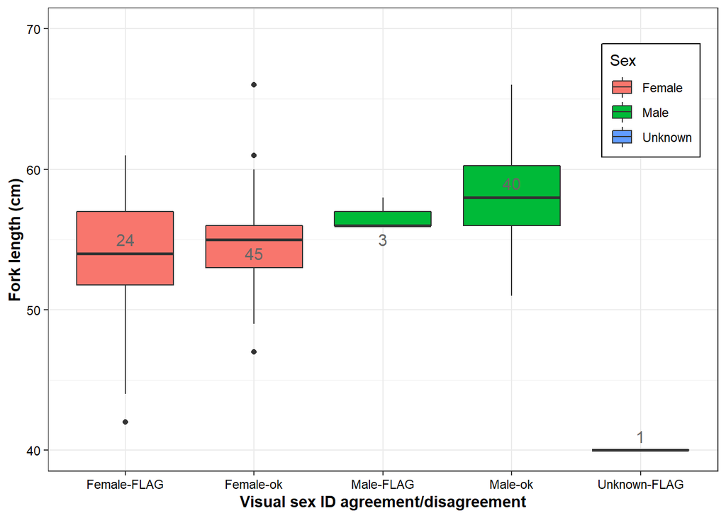

*Figure 2. Fork length (cm) of sockeye visually identified as female (pink) and male (green) at the Bridge River fence grouped by agreement ('ok') or disagreement ('FLAG') with their genetic sex ID. For example, 'Female-FLAG' indicates sockeye visually called females that later screened as genetically male. One fish of unknown phenotypic sex was later assigned as a male. Sample sizes given in gray for each group.*

## GSID and strays

IN PROGRESS

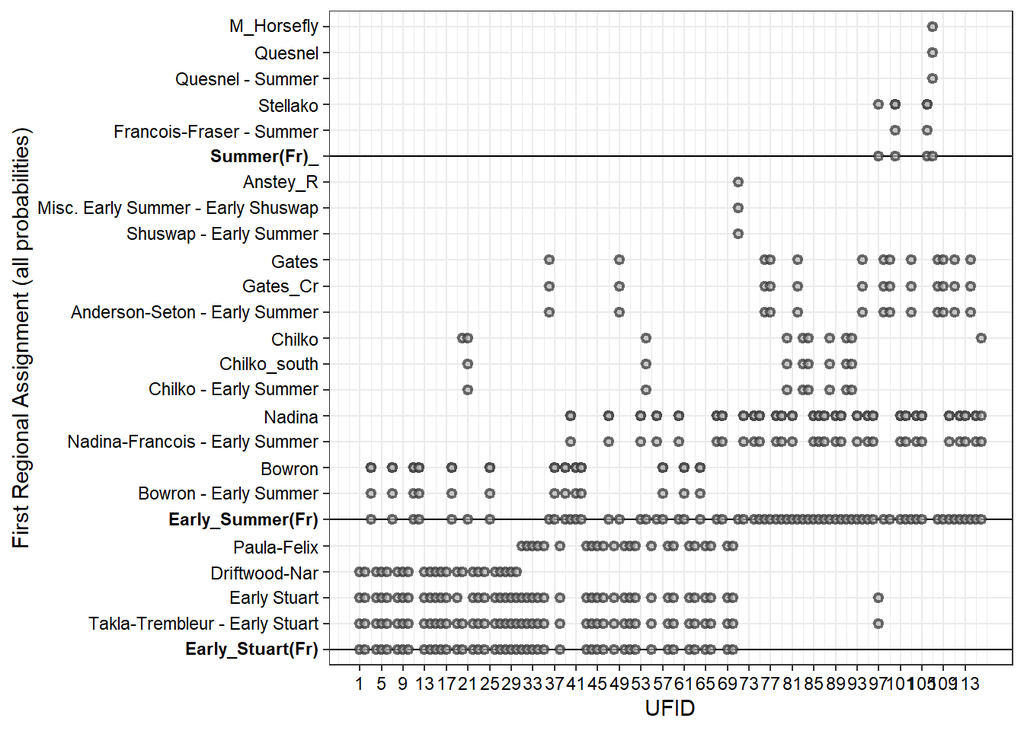

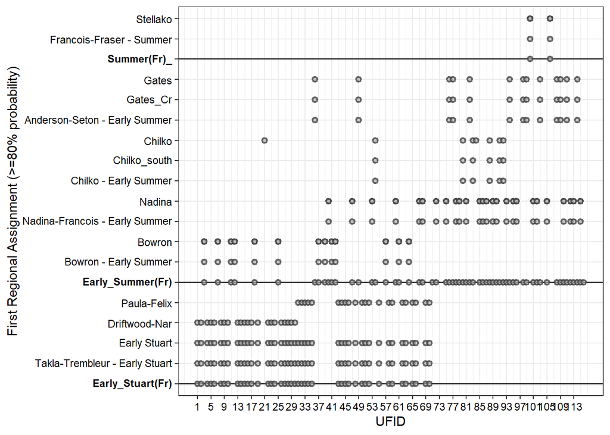

Figure 3 shows some interesting fine-scale temporal changes in GSID presence over time, for example the transition from Driftwood Early Stuarts to Paula/Felix Early Stuarts. High-level examination of those sockeye genetically assigned to a stock with >= 80% certainty shows clear changes over time in stock presence as would be expected based on their run timing (Figure 4).

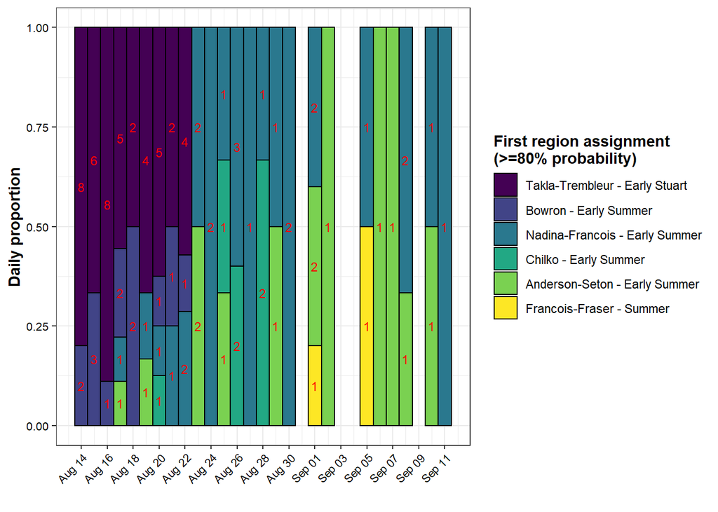

*Figure 4. Daily proportion of each stock encountered at the Bridge River fence in 2020. Text indicates sample sizes for each bar. Stocks shown are only those with >= 80% assignment probability.*